# Heart Transplant Mortality Rate

##### Key idea:

- implement Hierarchial model in chap 7 R texbook
- Poisson, Gamma distribution

##### Install libraries

```r
library(LearnBayes)
data(hearttransplants)
attach(hearttransplants)
```

PRIOR ~ $Gamma$(alpha, beta) has parameter alpha and beta

```r
alpha = 16; beta = 15174
```

Prior mean

```r
lam = alpha/beta
y = 0:10 #prior data from 10 hospitals
```

**Sampling** from hospital A

```r
yobs = 1; ex=66
```

**Predict** mortality of 10 hospitals predictive density = (sampling*prior)/posterior

```r
py=dpois(y, lam*ex) *dgamma(lam, shape= alpha, rate = beta)/dgamma(lam,
                                        shape = alpha + y, rate = beta + ex )
cbind(y, round(py, 3))
```

```
##        y
##  [1,]  0 0.933
##  [2,]  1 0.065
##  [3,]  2 0.002
##  [4,]  3 0.000
##  [5,]  4 0.000
##  [6,]  5 0.000
##  [7,]  6 0.000
##  [8,]  7 0.000
##  [9,]  8 0.000
## [10,]  9 0.000
## [11,] 10 0.000
```

The posterior density of λ can be summarized by **simulating** 1000 values from the $gamma$ density

```r
lambdaA = rgamma(1000, shape = alpha + yobs, rate = beta+ex)
```

Consider another hopsital B with y_obs=4, exposure e = 1767

```r
ex = 1767; yobs=4
y=0:10
py=dpois(y, lam*ex)*dgamma(lam, shape = alpha, rate = beta)/dgamma(lam,shape=alpha+y, rate = beta+ex)
cbind(y, round(py, 3))
```

```
##        y
##  [1,]  0 0.172
##  [2,]  1 0.286
##  [3,]  2 0.254
##  [4,]  3 0.159
##  [5,]  4 0.079
##  [6,]  5 0.033
##  [7,]  6 0.012
##  [8,]  7 0.004
##  [9,]  8 0.001
## [10,]  9 0.000
## [11,] 10 0.000
```

Posterior mean

```r
lambdaB= rgamma(1000, shape=alpha+yobs, rate =beta+ex)
```

#### Graph

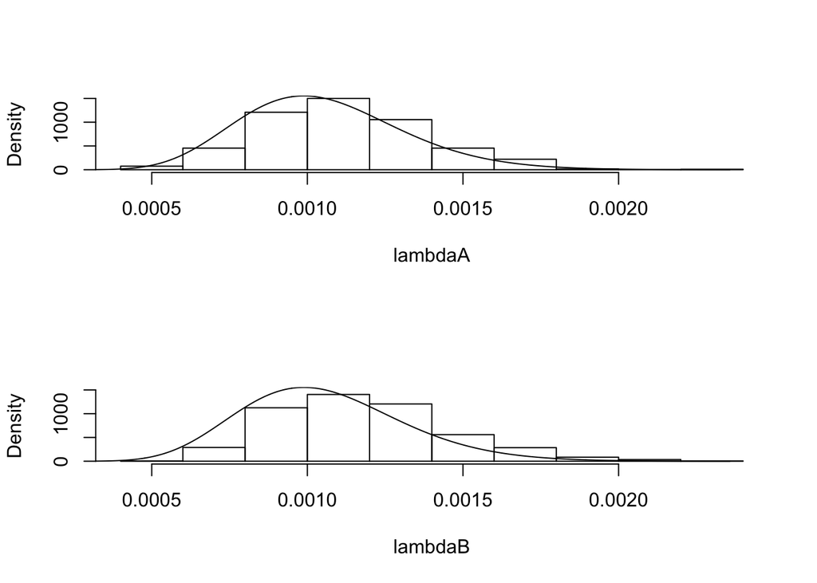

```r
lambda=seq(0, max(c(lambdaA, lambdaB)), length=500)
par(mfrow=c(2, 1))
hist(lambdaA, freq=FALSE, main=" ", ylim = c(0, 1500))
lines(lambda, dgamma(lambda, shape = alpha, rate = beta))
hist(lambdaB, freq= FALSE, main=" ", ylim=c(0, 1500))
lines(lambda, dgamma(lambda, shape=alpha, rate = beta))
```

–> Hospital A with relatively little experience in surgeries, the prior information is significant and the posterior distribution resembles the prior distribution

–> For hospital B with many surgeries, the prior information is less influential and the posterior distribution resembles the likelihood function